# Pratical Machine Learning Project

Vinícius T. Manjabosco

24-01-2015

We use data from accelerometers on the belt, forearm, arm, and dumbell of 6 participants and our goal is to predict the manner in which the participants did barbell lifts, correctly and incorrectly in 5 different ways, denoted by the “classe” variable in the training set.

## Loading Data

```r
# Load data
training <- read.csv('pml-training.csv', header = T)
testing <- read.csv('pml-testing.csv', header = T)
```

## Cleaning Data

```r
library(dplyr, warn.conflicts = F)

colTBU <- intersect(names(training), names(testing))

# Remove identifier columns
identColumns <- c('X', 'user_name')
colTBU <- setdiff(colTBU, identColumns)

# Remove Time related columns
timeColumns <- c('raw_timestamp_part_1', 'raw_timestamp_part_2', 'cvtd_timestamp')
colTBU <- setdiff(colTBU, timeColumns)

# Remove Na Columns
naColumnsTrain <- sapply(training, function(x) any(is.na(x)))
naColumnsTrain <- names(naColumnsTrain[naColumnsTrain])

naColumnsTest <- sapply(testing, function(x) any(is.na(x)))
naColumnsTest <- names(naColumnsTest[naColumnsTest])

naColumns <- union(naColumnsTrain, naColumnsTest)
colTBU <- setdiff(colTBU, naColumns)

# Remove Columns
training <- training[, c(colTBU, 'classe')]
```

We removed the following columns: * Columns containing identification * Columns containing timestamp * Columns containing NAs

```r
# Convert factor columns to numeric
for(n in colTBU) {
  if(is.factor(training[, n]) &&
     !(n %in% c('classe', 'new_window'))) {
    training[, n] <- as.numeric(training[, n])
    testing[, n] <- as.numeric(testing[, n])
  }
}
```

We also converted some factors columns to numeric.

## Training

In order to do the training we choose the Random Forest method which is known to make highly accurate predictions. We used a sample of 5000 observations and set its number of trees to 100 and define a 5-fold cross-validation method in the train control.

```r
library(caret, warn.conflicts = F)
set.seed(123)

sampleSize <- 5000
samples <- sample(nrow(training), sampleSize)
nTrees <- 100

fit <- train(classe ~ ., data = training[samples,],
             method = 'rf', prox = T, ntree = nTrees,
             trControl = trainControl('cv', number = 5))
fit
```

```
## Random Forest
##
## 5000 samples
##   54 predictor
##    5 classes: 'A', 'B', 'C', 'D', 'E'
##
## No pre-processing
## Resampling: Cross-Validated (5 fold)
##
## Summary of sample sizes: 4000, 4000, 4002, 3999, 3999
##
## Resampling results across tuning parameters:
##
##   mtry  Accuracy   Kappa      Accuracy SD  Kappa SD
##    2    0.9736028  0.9666122  0.005110257  0.006472225
##   28    0.9857992  0.9820443  0.003900773  0.004934276
##   54    0.9810016  0.9759816  0.002433821  0.003077661
##
## Accuracy was used to select the optimal model using  the largest value.
## The final value used for the model was mtry = 28.
```

The selected model has mtry = 28 and an accuracy of 98.5% as it can be seen in the following plot

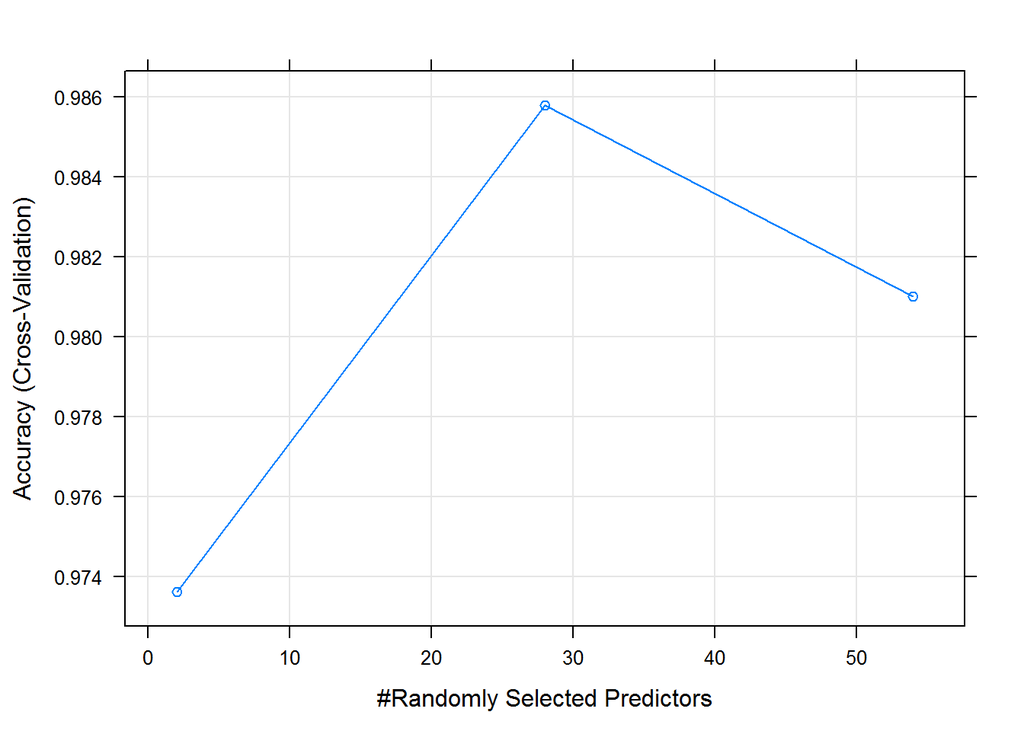

```r
plot(fit)
```

```r
fit$finalModel
```

```
##
## Call:
##  randomForest(x = x, y = y, ntree = ..2, mtry = param$mtry, proximity = ..1)
##                Type of random forest: classification
##                      Number of trees: 100
## No. of variables tried at each split: 28
##
##         OOB estimate of  error rate: 1.3%
## Confusion matrix:
##      A   B   C   D   E class.error
## A 1407   2   0   2   1 0.003541076
## B   12 964  10   0   0 0.022312373
## C    0   9 837   3   0 0.014134276
## D    0   0  15 829   2 0.020094563
## E    1   1   1   6 898 0.009922822
```

The Out of Sample(OOB) rate is pretty low 1.3%, we should expect a larger error rate in the test set.

## Prediction

Finally, we use our trained model in order to predict the outcomes for the testing set. Considering our OOB error rate, we should expect at least 1 misclassification every 76 cases.

```r
predict(fit, testing)
```

```
##  [1] B A B A A E D B A A B C B A E E A B B B
## Levels: A B C D E
```

Our testing set has just 20 cases and, as it turns out, our model was able to predict correctly each and every one of them.